# chương 4 trich tu bo hoang oppa

**Câu 4.** Phản ứng nhiệt hạch chỉ xảy ra dưới điều kiện áp suất và nhiệt độ rất cao. Một ví dụ về nơi có thể xảy ra những điều kiện ấy, và cho phép phản ứng nhiệt hạch xảy ra là

**A.** trong những lò luyện kim loại.

**B**. trên bề mặt tự nhiên của Trái Đất.

**C.** # trong lòng Mặt Trời.

**D.** trên bề mặt Mặt Trời.

**Câu 8.** Trong các hạt sau, hạt nào có khối lượng nghỉ lớn nhất? Hạt neutron, hạt proton, hạt electron, hạt positron.

**A.** # Hạt neutron.

**B**. Hạt positron.

**C.** Hạt proton.

**D.** Hạt electron.

**Câu 12.** Khi sử dụng cùng một khối lượng nhiên liệu, đâu là loại nhiên liệu có thể cung cấp nhiều năng lượng nhất?

**A.** nhiên liệu phản ứng phân hạch.

**B**. # nhiên liệu phản ứng nhiệt hạch.

**C.** than đá.

**D.** thuốc nổ TNT.

**Câu 16.** Cho hai mẫu chất phóng xạ giống hệt nhau. Khi ghép hai mẫu này lại làm một thì đại lượng sẽ thay đổi là

**A. #** độ phóng xạ.

**B**. chu kì bán rã.

**C.** khối lượng riêng.

**D.** hằng số phóng xạ.

[HD] vì độ phóng xạ tỉ lệ với số phân tử, nên khi ghép chúng lại, tổng số phân tử sẽ tăng lên, độ phóng xạ tăng lên

**Câu 2 (Đ/S).** Một mẫu chất có chứa đồng vị phóng xạ X. Người ta dùng một máy đếm electron có độ chính xác rất cao để xác định hoạt độ phóng xạ của mẫu chất. Trong 1 phút, người ta đếm được có 355 electron bắn ra từ mẫu này. Sau đó 5 giờ, trong 1 phút, số electron đếm được là 344.

a) X là một đồng vị phóng xạ $\beta^{+}$

b) Hoạt độ phóng xạ trung bình của X trong 1 phút ở lần đếm đầu tiên là 6,03 Bq.

c) Chu kì bán rã của X là khoảng 10 giờ.

d) # Sau 5 giờ nữa, thực hiện lại phép đếm trên trong 1 phút thì độ phóng xạ trung bình lúc đó là 5,56 Bq.

[HD]  
**a) SAI** *Vì máy đếm phát hiện các hạt electron nên đây là phóng xạ* $\beta^{-}$  
**b) SAI** *Độ phóng xạ trung bình trong khoảng thời gian*

[figure not shown]

là thương số giữa số phóng xạ xảy ra $\Delta N$ và thời gian

[figure not shown]

đó $H_{1} = \frac{\Delta N}{\Delta t} = \frac{355}{60} \approx \text{5,92 Bq}.$  
**c) SAI**  
*Lập tỉ số độ phóng xạ trung bình trong hai lần đo* $H_{1} = \frac{N_{0}\left( 1 - 2^{- \frac{\Delta t}{T}} \right)}{\Delta t},\quad H_{2} = \frac{N_{0}\left( 2^{- \frac{\Delta t + 5}{T}} - 2^{- \frac{\Delta t + 5 + \Delta t}{T}} \right)}{\Delta t} = 2^{- \frac{5 + \Delta t}{T}}H_{1}\quad \Rightarrow \quad\frac{H_{2}}{H_{1}} = 2^{- \frac{5 + \Delta t}{T}} = 2^{- \frac{5 + \frac{1}{60}}{T}} = \frac{344}{355}\quad \Rightarrow \quad T \approx \text{110,47}.$  
**d) ĐÚNG** *Tương tự, độ phóng xạ trung bình sau 5 giờ nữa là* $H_{3} = H_{1}2^{- \frac{5 + 5 + 2\Delta t}{T}} \approx \text{5,92} \times 2^{- \frac{5 + 5 + \frac{2}{60}}{110,1}} \approx \text{5,56 Bq}.$

**Câu 15.** Năng lượng liên kết của một hạt nhân được xác định bằng

**A.** năng lượng liên kết trung bình của mỗi nucleon trong hạt nhân.

**B.** năng lượng cần thiết để tách một nucleon ra khỏi hạt nhân.

**C.** # năng lượng cần thiết để tách rời tất cả các nucleon trong hạt nhân.

**D.** tích của khối lượng hạt nhân với bình phương tốc độ ánh sáng trong chân không.

**Câu 16.** Hạt nhân uranium $_{92}^{235}U$ có năng lượng liên kết riêng là 7,59 MeV/nucleon. Lấy 1 uc<sup>2</sup> = 931,5 MeV. Độ hụt khối của hạt nhân $_{92}^{235}U$ xấp xỉ bằng

**A.** 1,98.10<sup>−14</sup> u.

**B.** # 1,91 u.

**C.** 1,98.10<sup>−14</sup> kg.

**D.** 1,91 g.

**[HD]** *Ta có:* $E_{lkr} = \frac{E_{lk}}{A} = \frac{\mathrm{\Delta}m.c^{2}}{A}$ *⇔* $\mathrm{\Delta}m = \frac{A.E_{lkr}}{c^{2}} = \frac{235.7,59}{\frac{931,5}{u}} \approx 1,91u$*.*

**Câu 17.** Trong y học hạt nhân, một loại đồng vị phóng xạ được dùng để đánh dấu sinh học. Sau khi chuẩn bị xong, người ta theo dõi độ phóng xạ của chất này và nhận thấy rằng sau 3 giờ, số hạt nhân phóng xạ trong mẫu chỉ còn 25% so với ban đầu. Chu kì bán rã của đồng vị phóng xạ đó bằng

**A.** # 1,5 giờ.

**B.** 6 giờ.

**C.** 4,5 giờ.

**D.** 3 giờ.

**[HD]** *Ta có:* $\%\ còn = 2^{- \frac{t}{T}}$ *⇔* $0,25 = 2^{- \frac{3}{T}}$ *⇒* $T = 1,5$ *giờ.*

**Câu 18.** Xét phản ứng nhiệt hạch: $_{1}^{2}H$ + $_{1}^{2}H$ → $_{2}^{4}{He}$ có năng lượng tỏa ra là 3,25 MeV. Nếu quá trình nhiệt hạch sử dụng hết 150 g $_{1}^{2}H$ thì tổng năng lượng thu được xấp xỉ bằng

**A.** 7,34 MeV.

**B.** # 7,34.10<sup>25</sup> MeV.

**C.** 14,7 MeV.

**D.** 1,47.10<sup>26</sup> MeV.

**[HD]** *Mỗi phản ứng nhiệt hạch đang xét cần sử dụng 2 hạt* $_{1}^{2}H$*. Do đó, số lượng phản ứng nhiệt hạch khi sử dụng hết 150 g* $_{1}^{2}H$ *là: N =* $\frac{N_{H2}}{2}$ *=* $\frac{150}{4}$*.6,02.*$10^{23}$ *= 2,2575.*$10^{25}$  
Tổng năng lượng thu được:  
W = 2,2575.$10^{25}$*.3,25 ≈ 7,34.*$10^{25}$ *MeV.*

**Câu 2.** Trong một nguyên tử, khối lượng tập trung hầu hết ở

**A.** lớp vỏ electron.

**B. #** hạt nhân của nguyên tử.

**C.** trong khoảng không giữa hạt nhân và lớp vỏ electron.

**D.** các hạt proton trong hạt nhân của nguyên tử.

**Câu 8.** Các đồng vị của một nguyên tố sẽ **không** khác nhau về

**A.** hằng số phóng xạ.

**B.** # điện tích hạt nhân.

**C.** khối lượng hạt nhân.

**D.** số neutron trong hạt nhân.

**Câu 14.** Xét một mẫu chất phóng xạ nguyên chất, chứa 100% đồng vị phóng xạ của nguyên tố X. Đại lượng tỉ lệ thuận với số hạt nhân X trong mẫu là

**A.** hằng số phóng xạ.

**B.** chu kì bán rã.

**C.** # độ phóng xạ.

**D.** năng lượng của tia phóng xạ.

**Câu 15.** Xét phản ứng hạt nhân sau $_{2}^{4}\text{He} +_{2}^{4}\text{He} \rightarrow_{3}^{7}\text{Li} + n$. Đây là phản ứng

**A.** # nhiệt hạch.

**B.** phân hạch dây chuyền.

**C.** phân hạch.

**D.** phóng xạ.

**Câu 18.** Loại tia phóng xạ có tốc độ bằng với tốc độ ánh sáng là

**A.** tia

[figure not shown]

**B.** tia $\beta^{+}.$

**C.** tia $\beta^{-}.$

**D.** # tia γ

**Câu 4 (Đ/S).** Mặt Trời là một ngôi sao đang phát sáng và tỏa nhiệt nhờ vào nguồn năng lượng nhiệt hạch dồi dào trong lòng của nó. Xét một trong những phản ứng nhiệt hạch tỏa năng lượng cao là
$$_{1}^{2}D +_{1}^{3}T \rightarrow X
+_{0}^{1}\text{n.}$$
Năng lượng tỏa ra từ một phản ứng này là 17,8 MeV. Các nhà vật lý hiện đại đã tính toán được ngưỡng động năng của các hạt tham gia phản ứng để kích hoạt được phản ứng là 0,065 MeV. Dưới ngưỡng động năng này, lực đẩy tĩnh điện giữa các hạt nhân làm giảm đáng kể xác suất xảy ra phản ứng. Vì động năng của các hạt nhân là rất lớn so với thế năng tương tác giữa chúng, và vì kích thước của các hạt nhân là rất nhỏ, các nhà vật lý có thể xem lòng Mặt Trời là một khối khí lý tưởng, gồm các hạt nhân nhẹ như $_{1}^{2}D$, $_{1}^{3}T$, $_{2}^{4}\text{He}.$ Cho $\text{1 amu} = \text{931,5 MeV/}\text{c}^{2}.$

a) # $_{1}^{2}D$ và $_{1}^{3}T$là những đồng vị của Hydrogen.

b) Hạt nhân X là $_{2}^{3}\text{He}.$

c) So với trước phản ứng, tổng khối lượng nghỉ của các hạt sau phản ứng đã giảm 0,191 amu.

d) # Giả sử các hạt nhân tham gia phản ứng có động năng trung bình bằng ngưỡng kích hoạt phản ứng. Nhiệt độ của lòng Mặt Trời theo mô hình khí lý tưởng là khoảng $502,4 \times 10^{6}\ \text{K.}$

[HD]  
**a) ĐÚNG** *Vì điện tích hạt nhân là 1e nên chúng là đồng vị của Hydrogen.*  
**b) SAI** *Bảo toàn số khối, suy ra* $A_{X} = 2 + 3 - 1 = 4.$ *Bảo toàn điện tích, suy ra* $Z_{X} = 1 + 1 - 0 = 2.$ *Vậy X là* $_{2}^{4}\text{He}.$  
**c) SAI**  
*Độ lớn độ giảm năng lượng nghỉ là* $|\Delta m| = \frac{\left| \Delta E_{n} \right|}{c^{2}} = \frac{|\Delta K|}{c^{2}} = \text{17,8}\frac{\text{MeV}}{c^{2}} = \frac{\text{17,8}}{\text{931,5}}\left( \text{931,5 }\frac{\text{MeV}}{c^{2}} \right) \approx \text{0,0191 amu}.$  
**d) ĐÚNG** *Áp dụng mô hình khí lý tưởng cho các hạt nhân nhẹ có động năng trung bình là 0,065 MeV:* $\overline{W_{d}} = \frac{3}{2}kT\quad \Rightarrow \quad T = \frac{2\overline{W_{d}}}{3k} = \frac{2 \times \text{0,065} \times \text{1,6} \times 10^{- 13}}{3 \times \text{1,38} \times 10^{- 23}} \approx \text{502,4} \times 10^{6}\ K.$

**Câu 16.** Dược chất phóng xạ̣ flortaucipir (chứa $_{9}^{18}F$ là đồng vị phóng xạ β<sup>+</sup>) được tiêm vào bệnh nhân khi chụp PET. Biết rằng cứ sau 110 phút thì lượng $_{9}^{18}F$ trong dược chất giảm đi một nửa. Hằng số phóng xạ của $_{9}^{18}F$ xấp xỉ bằng

**A.** 0,21.10<sup>−3</sup> s<sup>−1</sup>.

**B.** # 0,11.10<sup>−3</sup> s<sup>−1</sup>.

**C.** 0,42.10<sup>−3</sup> s<sup>−1</sup>.

**D.** 0,84.10<sup>−3</sup> s<sup>−1</sup>.

**[HD]**  
*Do cứ sau 110 phút thì lượng* $_{9}^{18}F$ *trong dược chất giảm đi một nửa nên chu kì bán rã của* $_{9}^{18}F$ là T = 110 phút.  
Hằng số phóng xạ của $_{9}^{18}F$ *bằng:* $\lambda = \frac{\ln 2}{T} = \frac{\ln 2}{110.60} \approx 0,11.10^{- 3}$ *s<sup>−1</sup>.*

**Câu 17.** Một mẫu chất chứa đồng vị phóng xạ $_{27}^{60}{Co}$ có chu kì bán rã 5,27 năm, được sử dụng trong điều trị ung thư. Gọi $\mathrm{\Delta}N_{0}$ là số hạt nhân $_{27}^{60}{Co}$ phân rã trong 1 phút của mẫu ngay khi mới được sản xuất. Mẫu chất cần được thay mới khi số hạt nhân $_{27}^{60}{Co}$ phân rã trong 1 phút của mẫu giảm xuống nhỏ hơn $0,6\mathrm{\Delta}N_{0}$. Sau bao nhiêu năm, kể từ thời điểm sản xuất, thì mẫu chất này cần được thay mới (Kết quả được làm tròn đến chữ số hàng phần trăm)?

**A.** 2,71 năm.

**B.** # 3,88 năm.

**C.** 9,15 năm.

**D.** 6,97 năm.

**[HD]**  
*Tại thời điểm sản xuất, ta có:* $\mathrm{\Delta}N_{0} = N_{0}\left( 1 - 2^{- \frac{\mathrm{\Delta}t}{T}} \right)$  
*Tại thời điểm t trước thời điểm mẫu chất cần được thay mới ∆t = 1 phút, ta có:*  
$\mathrm{\Delta}N = 0,6.\mathrm{\Delta}N_{0}$ *⇔* $N_{0}.2^{- \ \frac{t}{T}}\left( 1 - 2^{- \ \frac{\mathrm{\Delta}t}{T}} \right) = 0,6.N_{0}\left( 1 - 2^{- \ \frac{\mathrm{\Delta}t}{T}} \right)$  
*⇔* $2^{- \ \frac{t}{T}} = 0,6 = 2^{- \frac{t}{5,27}}$ *⇒* $t \approx 3,88$ năm.  
Do ∆t = 1 phút rất nhỏ so với $t \approx 3,88$ *năm nên sau khoảng 3,88 năm kể từ thời điểm sản xuất, thì mẫu chất này cần được thay mới.*

**Câu 18.** Một phòng thí nghiệm Vật lí hạt nhân có sử dụng nguồn phóng xạ để nghiên cứu. Để đảm bảo an toàn, tại khu vực đặt nguồn phóng xạ cần treo biển báo ở hình nào dưới đây?

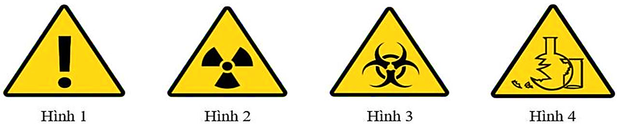

**A.** Hình 3.

**B.** Hình 1.

**C.** Hình 4.

**D.** # Hình 2.

**[HD]** Hình 1 là biển báo cảnh báo chung về khu vực nguy hiểm.  
Hình 2 là biển báo cảnh báo khu vực nguy hiểm có chất phóng xạ.  
Hình 3 là biển báo cảnh báo khu vực nguy hiểm có chất độc sinh học.  
Hình 4 là biển báo cảnh báo khu vực nguy hiểm do thủy tinh.

**Câu 3:** Đâu **không phải** là nội dung trong mô hình nguyên tử của Rutherford?

**A.** Ở trung tâm nguyên tử có một hạt nhân.

**B.** # Điện tích dương của nguyên tử phân bố đều khắp nguyên tử.

**C.** Toàn bộ khối lượng của nguyên tử tập trung ở hạt nhân.

**D.** Các electron mang điện tích âm chuyển động xung quanh hạt nhân.

**Câu 6:** Tia phóng xạ nào sau đây **không** mang điện tích?

**A.** Tia α.

**B.** Tia β<sup>+</sup>.

**C.** Tia β<sup>–</sup>.

**D.** # Tia γ.

**Câu 8:** Một hạt nhân Oxygen có 8 proton và 8 neutron được ký hiệu là

**A.** $_{8}^{8}O.$

**B. #** $_{8}^{16}O.$

**C.** $_{16}^{8}O.$

**D.** $_{8}^{24}O.$